# Tugas Analisis Multimedia: Audio, Gambar, Video

**Mata Kuliah:** Sistem & Teknologi Multimedia  
**Nama:** Lucky Immanuel Sitanggang  
**NIM:** 122140179

## Deskripsi Tugas

Tugas ini bertujuan untuk memahami representasi dasar data multimedia (audio, gambar, dan video) melalui praktik langsung memuat data, visualisasi, dan ekstraksi informasi fundamental. Anda akan bekerja dengan tiga jenis media berbeda untuk menganalisis karakteristik temporal (audio), spasial (gambar), dan spatio-temporal (video).

Fokus tugas adalah pada pemahaman konsep dasar representasi multimedia dan kemampuan interpretasi hasil visualisasi, **bukan** pada manipulasi atau transformasi lanjutan data multimedia.

## ⚠️ CATATAN PENTING: PRESENTASI ACAK & KEJUJURAN AKADEMIK

**Sebagian mahasiswa akan dipilih secara ACAK untuk presentasi singkat** (5-10 menit) menjelaskan kode dan interpretasi hasil mereka. Jika Anda:

- Tidak mampu menjelaskan kode yang Anda kumpulkan
- Hanya menyalin-tempel tanpa pemahaman
- Bergantung sepenuhnya pada AI tanpa memahami konsep

**Maka nilai tugas Anda akan diberikan 0 (nol).**

Gunakan referensi dan AI sebagai alat bantu pembelajaran, tetapi pastikan Anda memahami setiap baris kode dan dapat menjelaskan logika di baliknya.

```python
# Import Library (Satu-satunya sel kode dalam template ini)
import numpy as np
import matplotlib as mpl
import matplotlib.pyplot as plt
import librosa
import soundfile as sf
from PIL import Image
import cv2
from IPython.display import Audio, HTML, display
import os

# Set matplotlib untuk menampilkan plot inline
%matplotlib inline

# Tampilkan versi library untuk dokumentasi
print("Library versions:")
print(f"NumPy: {np.__version__}")
print(f"Matplotlib: {mpl.__version__}")
print(f"Librosa: {librosa.__version__}")
print(f"OpenCV: {cv2.__version__}")

# Tambahkan import lain jika diperlukan saat mengerjakan tugas
```

```
Library versions:
NumPy: 1.26.4
Matplotlib: 3.10.1
Librosa: 0.11.0
OpenCV: 4.8.1
```

## Petunjuk Umum Pengerjaan

### 📋 Cara Menggunakan Template

- Gunakan notebook ini sebagai kerangka kerja utama
- Tulis penjelasan (markdown) **SEBELUM** menaruh kode agar maksud dan tujuan jelas
- Tambahkan sel kode di tempat yang sudah disediakan (tandai dengan TODO)
- Semua plot/gambar harus diberi judul, label sumbu, dan keterangan singkat

### 📊 Standar Visualisasi

- Setiap plot harus memiliki judul yang deskriptif
- Label sumbu X dan Y harus jelas
- Gunakan colorbar untuk plot yang memerlukan skala warna
- Berikan interpretasi singkat setelah setiap visualisasi

### 📂 Struktur Data yang Direkomendasikan

- Buat folder `data/` di direktori yang sama dengan notebook
- Gunakan nama file yang deskriptif (contoh: `audio_musik_piano.wav`, `gambar_pemandangan_gunung.jpg`)
- Dokumentasikan sumber data jika menggunakan dataset publik

### ⚠️ Larangan

- **Jangan** menaruh seluruh pekerjaan dalam satu sel kode yang sangat panjang
- **Jangan** menempel hasil output tanpa interpretasi atau analisis
- **Jangan** bergantung sepenuhnya pada AI - pahami dan kuasai kode Anda

### 🎯 Persiapan Presentasi Acak

- Pastikan Anda memahami setiap baris kode yang ditulis
- Latih menjelaskan logika dan alur pemikiran Anda
- Siapkan penjelasan untuk setiap visualisasi dan interpretasinya

## Checklist Kelengkapan (Centang ✅ saat selesai)

### 🎵 Bagian Audio

- [✅] Muat audio dan tampilkan metadata (durasi, sample rate, jumlah kanal)
- [✅] Tampilkan spectrogram dalam skala log-dB dengan colorbar
- [✅] Tampilkan waveform dengan label sumbu yang jelas
- [✅] Tampilkan MFCC (minimal 13 koefisien) sebagai heatmap
- [✅] Berikan interpretasi dan analisis untuk setiap visualisasi audio

### 🖼️ Bagian Gambar

- [✅] Tampilkan gambar dengan benar dalam format RGB
- [✅] Tampilkan informasi dasar (dimensi, jumlah kanal, dtype)
- [✅] Tampilkan histogram warna untuk channel R, G, B
- [✅] Berikan analisis hubungan histogram dengan kesan visual gambar

### 📹 Bagian Video

- [✅] Tampilkan metadata video (resolusi, fps, frame count, durasi)
- [✅] Tampilkan 3 frame representatif (awal, tengah, akhir)
- [✅] Konversi BGR ke RGB dengan benar untuk visualisasi
- [✅] Analisis kesesuaian parameter video dengan use case

### 📝 Analisis & Dokumentasi

- [✅] Setiap bagian memiliki interpretasi dan analisis ringkas
- [✅] Perbandingan representasi ketiga jenis media
- [✅] Kesimpulan pembelajaran dan refleksi
- [✅] Semua sumber data dan referensi dicantumkan

# Pendahuluan

## Apa itu Data Multimedia?

Data multimedia adalah informasi yang dikodekan dalam berbagai format untuk merepresentasikan dunia nyata:

- **Audio (1D)**: Sinyal satu dimensi yang berubah terhadap waktu
  - Contoh: musik, suara, speech
  - Representasi: amplitudo vs waktu
- **Gambar (2D)**: Matriks nilai intensitas dalam ruang dua dimensi
  - Contoh: foto, ilustrasi, grafik
  - Representasi: intensitas pixel pada koordinat (x,y)
- **Video (2D + Waktu)**: Rangkaian frame (gambar) yang ditampilkan berurutan
  - Contoh: film, rekaman, animasi
  - Representasi: frame berubah terhadap waktu dengan frame rate tertentu

## Tujuan Tugas

Memahami representasi dasar dan teknik visualisasi fundamental untuk setiap jenis media multimedia, termasuk:

- Cara memuat dan membaca file multimedia
- Ekstraksi informasi metadata yang penting
- Visualisasi yang informatif dan mudah dipahami
- Interpretasi hasil analisis secara kontekstual

## Cara Kerja

1. Isi setiap bagian sesuai instruksi yang diberikan
2. Tambahkan sel kode di tempat yang ditandai dengan "TODO"
3. Berikan interpretasi dan analisis setelah setiap visualisasi
4. Pastikan semua plot memiliki judul, label, dan keterangan yang jelas

# Bagian A — Audio

### A1. Deskripsi Data

**TODO:** Jelaskan audio yang akan Anda analisis:

- Jenis audio: Musik
- Sumber: Youtube.
- Format file: WAV
- Alasan pemilihan: Lagu favorite saya

**Path file:** `data/audio_musik_showyou.wav` (isi nama file Anda nanti di kode)

### A2. TODO: Muat & Metadata

**Instruksi:** Tulis kode untuk memuat file audio dan menampilkan metadata dasar:

- Sample rate (Hz)
- Durasi (detik)
- Jumlah kanal (mono/stereo)
- Jumlah total sampel

**Catatan:** Jika file MP3 bermasalah saat loading, gunakan format WAV sebagai alternatif.

```python
file_path = 'data/audio_musik_showyou.wav'

info = sf.info(file_path)

sample_rate = info.samplerate
n_channels = info.channels
n_frames = info.frames
duration = n_frames / float(sample_rate)

channel_label = 'mono' if n_channels == 1 else 'stereo'

print(f'File: {file_path}')
print(f'Sample Rate: {sample_rate} Hz')
print(f'Durasi : {duration:.2f} detik')
print(f'Jumlah kanal: {n_channels} ({channel_label})')
print(f'Jumlah total sampel: {n_frames}')
print(f'Jumlah total sampel semua kanal: {n_frames * n_channels}')
```

```
File: data/audio_musik_showyou.wav
Sample Rate: 48000 Hz
Durasi : 179.37 detik
Jumlah kanal: 2 (stereo)
Jumlah total sampel: 8609960
Jumlah total sampel semua kanal: 17219920
```

### A3. TODO: Waveform

**Instruksi:** Plot waveform audio dengan:

- Sumbu X: waktu (detik)
- Sumbu Y: amplitudo
- Judul dan label sumbu yang jelas

**Analisis yang diperlukan:** Jelaskan apa yang Anda lihat dari waveform (pola amplitudo, bagian keras/pelan, dll.)

-> yang saya lihat adalah musik ini memiliki 2 chanel sehingga right chanel menimpa left channel pada output ini dan amplitudo musik ini rata2 tinggi stabil di _+ 0.8 , ia pelan di intro dan keras selanjutnya dan kembali pelan kembali di pertengahan lagu di detik ke 118-125

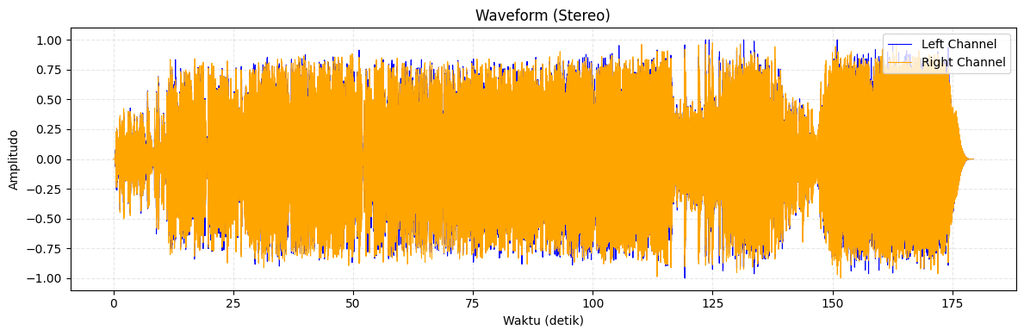

```python
file_path = 'data/audio_musik_showyou.wav'

y,sr = sf.read(file_path, always_2d=True)
n_frames, n_channels = y.shape
t = np.arange(n_frames) / sr

plt.figure(figsize=(12, 4))

if n_channels == 1:
    #Mono
    plt.plot(t, y[:,0],color='steelblue', linewidth=0.8)
    plt.title('Waveform (Mono)')
else:
    #Stereo
    plt.plot(t, y[:,0],color='blue', linewidth=0.8, label='Left Channel')
    plt.plot(t, y[:,1],color='orange', linewidth=0.8, label='Right Channel')
    plt.title('Waveform (Stereo)')
    plt.legend(loc='upper right')

plt.xlabel('Waktu (detik)')
plt.ylabel('Amplitudo')
plt.grid(alpha=0.3, linestyle='--')
plt.tight_layout()
```

### A4. TODO: Spectrogram log-dB

**Instruksi:** Hitung STFT dan tampilkan spectrogram dalam skala log-dB:

- Gunakan parameter standar (n_fft=1024, hop_length=256)
- Tampilkan dengan colorbar
- Label sumbu: waktu (detik) dan frekuensi (Hz)

**Analisis yang diperlukan:** Jelaskan perbedaan informasi yang didapat dari spectrogram dibanding waveform.

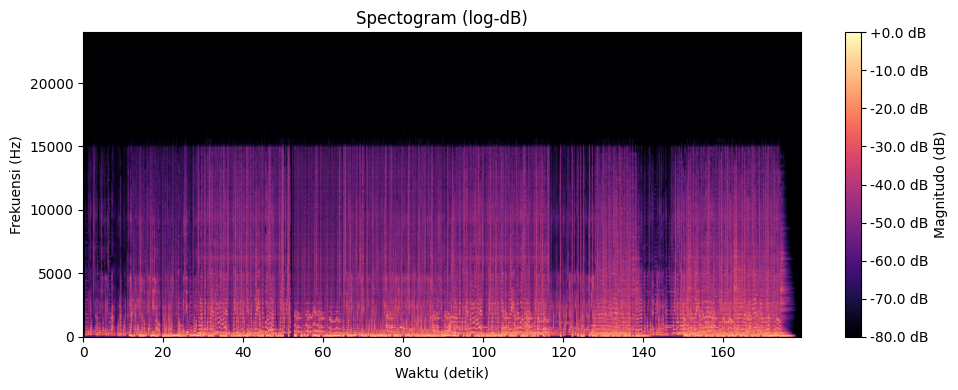

```python
y_mono = y[:,0] if y.shape[1] == 1 else y.mean(axis=1)

n_fft = 1024
hop_length = 256

# STFT ke dB
S = librosa.stft(y_mono, n_fft=n_fft, hop_length=hop_length, window = 'hann', center = True)
S_db = librosa.amplitude_to_db(np.abs(S), ref=np.max)

t_max = S_db.shape[1] * hop_length / sr
f_max = sr / 2
plt.figure(figsize=(10, 4))
im = plt.imshow(S_db, aspect='auto', origin='lower', cmap='magma',extent=[0, t_max, 0, f_max])
cbar = plt.colorbar(im, format='%+0.1f dB')
cbar.set_label('Magnitudo (dB)')
plt.title('Spectogram (log-dB)')
plt.xlabel('Waktu (detik)')
plt.ylabel('Frekuensi (Hz)')
plt.tight_layout()
plt.show()
```

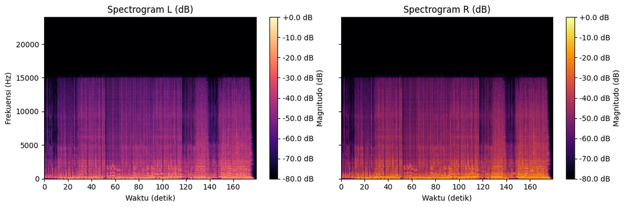

```python
# Misalnya audio y sudah stereo: shape (n_samples, 2), dan sr sudah ada
L = y[:, 0]
R = y[:, 1]

n_fft = 1024
hop_length = 256

# STFT untuk kiri dan kanan
SL = librosa.stft(L, n_fft=n_fft, hop_length=hop_length, window='hann', center=True)
SR = librosa.stft(R, n_fft=n_fft, hop_length=hop_length, window='hann', center=True)

# Konversi ke dB, gunakan max dari kedua channel biar skala konsisten
ref = max(np.abs(SL).max(), np.abs(SR).max())
SL_db = librosa.amplitude_to_db(np.abs(SL), ref=ref)
SR_db = librosa.amplitude_to_db(np.abs(SR), ref=ref)

# Hitung sumbu waktu dan frekuensi
t_max = SL_db.shape[1] * hop_length / sr
f_max = sr / 2
vmin = min(SL_db.min(), SR_db.min())
vmax = 0.0  # karena ref global max

# Plot dengan colormap berbeda
fig, axs = plt.subplots(1, 2, figsize=(12, 4), sharey=True)

im0 = axs[0].imshow(SL_db, origin='lower', aspect='auto',
                    extent=[0, t_max, 0, f_max], cmap='magma', vmin=vmin, vmax=vmax)
axs[0].set_title('Spectrogram L (dB)')
axs[0].set_xlabel('Waktu (detik)')
axs[0].set_ylabel('Frekuensi (Hz)')

im1 = axs[1].imshow(SR_db, origin='lower', aspect='auto',
                    extent=[0, t_max, 0, f_max], cmap='inferno', vmin=vmin, vmax=vmax)
axs[1].set_title('Spectrogram R (dB)')
axs[1].set_xlabel('Waktu (detik)')

# Tambahkan colorbar
cbar0 = fig.colorbar(im0, ax=axs[0], format='%+0.1f dB')
cbar0.set_label('Magnitudo (dB)')
cbar1 = fig.colorbar(im1, ax=axs[1], format='%+0.1f dB')
cbar1.set_label('Magnitudo (dB)')

plt.tight_layout()
plt.show()
```

### A5. TODO: MFCC

**Instruksi:** Hitung dan tampilkan minimal 13 koefisien MFCC sebagai heatmap:

- Sumbu X: waktu (frame)
- Sumbu Y: koefisien MFCC (1-13)
- Gunakan colorbar dan judul yang jelas

**Analisis yang diperlukan:** Interpretasi sederhana: apakah pola MFCC stabil atau berubah-ubah? Apa potensi maknanya?

pada koefesien rendah seperi antar 2-3 pola MFCC stabil sehingga membentuk garis merah tebal namun pada koefesien menengah dan tinggi pola tidak stabil sehingga membuat pola selang seling dan kurang tebal yang mana berarti musik ini punya dasar suara yang konsiosten tetapi ada perubahan konten suara sepanjang waktu

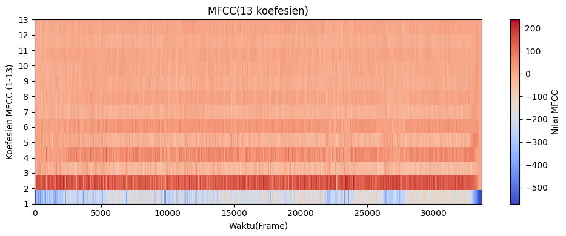

```python
mfcc = librosa.feature.mfcc(y=y_mono,sr=sr , n_mfcc=13, n_fft=n_fft, hop_length=hop_length)

T = mfcc.shape[1]
plt.figure(figsize=(10,4))
im = plt.imshow(mfcc, origin='lower' , aspect='auto' , extent= [0,T-1,1,13],cmap='coolwarm', interpolation='nearest')
plt.yticks(np.arange(1,14))
cbar = plt.colorbar(im)
cbar.set_label('Nilai MFCC')
plt.title('MFCC(13 koefesien)')
plt.xlabel('Waktu(Frame)')
plt.ylabel('Koefesien MFCC (1-13)')

plt.tight_layout()
plt.show()
```

### A6. Analisis Ringkas (Wajib)

**Jawab pertanyaan berikut:**

1. **Perbedaan insight:** Apa perbedaan informasi yang didapat dari waveform versus spectrogram?

   *Jawaban Anda:* MFCC memecah suara menjadi beberapa koefesien yang mempresentasikan energi dasar, bentuk spektrum, dan detail halus. yang mana jika suara konsisten akan menunjukkan pola yang stabil juga pada MFCC dan juga ini menunjukan bahwa audio bisa distrukturkan dan dipetakan ke dalam bentuk numerik juga.

# Bagian B — Gambar

### B1. Deskripsi Data

**TODO:** Jelaskan gambar yang akan Anda analisis:

- Jenis gambar: ilustrasi.
- Sumber: Pinterest.
- Format file: JPG.
- Alasan pemilihan: Wallpaper laptop saya. **Path file:** `data/wallpaper_drstone.jpg` (isi nama file Anda nanti di kode)

### B2. TODO: Baca & Tampilkan (RGB)

**Instruksi:** Baca gambar dan tampilkan dengan benar dalam format RGB:

- Pastikan konversi warna benar (ingat perbedaan BGR vs RGB di OpenCV)
- Berikan judul yang deskriptif
- Hilangkan axis untuk tampilan yang bersih

**Analisis yang diperlukan:** Jelaskan gambar secara ringkas (objek dominan, kondisi pencahayaan, komposisi warna).

Objek dominan dari gambar ini adalah karakter senku di tengah , bulan dan bintang . Pencahayaan terang yang berfokus pada tengah layar. Komposisi warna didominasi biru dan putih serta ada warna gelap hitam di sekitar background.

[figure not shown]

```python
img_path = 'data/wallpaper_drstone.jpg'
img_bgr = cv2.imread(img_path)
# img_rgb = cv2.cvtColor(img_bgr, cv2.COLOR_BGR2RGB)
img_rgb = img_bgr[:,:,::-1]
plt.imshow(img_bgr)
plt.imshow(img_rgb)
plt.title('Wallpaper Dr. Stone (RGB)')
plt.axis('off')
plt.tight_layout()
plt.show()
```

### B3. TODO: Informasi Dasar

**Instruksi:** Tampilkan informasi metadata gambar:

- Dimensi (Height × Width)
- Jumlah kanal
- Tipe data (dtype)
- Mode warna (jika relevan)
- Ukuran file dalam memori

**Analisis yang diperlukan:** Jelaskan mengapa informasi ini penting untuk tahap preprocessing atau analisis lanjutan.

Preprocessing ini berfungsi agar tahap preprocessing berikutnya (resize, konversi warna , dll) ridak salah langkah dan pas targetnya dan hasil visualisasi sesuai dengan apa yang diinginkan serta fitur yang ingin diubah tidak salah.

```python
if img_bgr.ndim == 2:
    H , W = img_bgr.shape
    channels = 1
else:
    H, W, channels = img_bgr.shape

dtype = img_bgr.dtype
mem_bytes = img_bgr.nbytes

pil_mode = None
try:
    with Image.open(img_path) as pil_img:
        pil_mode = pil_img.mode  # 'RGB', 'RGBA', 'L', dll.
except Exception:
    pil_mode = None

cv_hint = (
    "Gray (OpenCV)" if channels == 1 else
    "BGR (OpenCV)" if channels == 3 else
    "BGRA (OpenCV)" if channels == 4 else
    f"{channels}-channel (OpenCV)"
)

def fmt_bytes(n):
    units = ['B', 'KB', 'MB', 'GB', 'TB']
    f, i = float(n), 0
    while f>= 1024 and i < len(units) -1 :
        f /= 1024.0
        i += 1
    return f"{f:.2f} {units[i]}"

print("Metadata Gambar")
print(f"Dimensi (HxW): {H} x {W}")
print(f"Jumlah kanal: {channels}")
print(f"Tipe data (dtype): {dtype}")
print(f"Mode Warna: {pil_mode if pil_mode else cv_hint} ")
print(f"Ukuran dalam memori: {fmt_bytes(mem_bytes)}({mem_bytes}bytes)")
```

```
Metadata Gambar
Dimensi (HxW): 414 x 736
Jumlah kanal: 3
Tipe data (dtype): uint8
Mode Warna: RGB
Ukuran dalam memori: 892.69 KB(914112bytes)
```

### B4. TODO: Histogram Warna

**Instruksi:** Tampilkan histogram distribusi intensitas untuk channel R, G, B:

- Range: 0-255
- Plot terpisah atau overlay dengan warna sesuai channel
- Label sumbu: intensitas pixel dan frekuensi
- Legend yang jelas

**Analisis yang diperlukan:** Analisis: channel mana yang dominan? Bagaimana kontras gambar? Seperti apa sebaran intensitasnya?

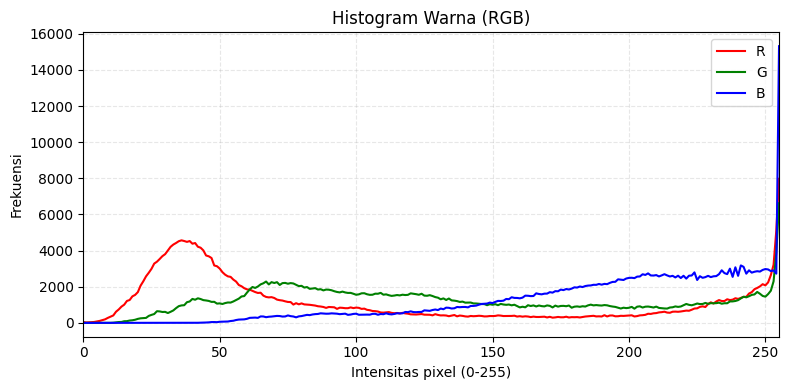

```
Kanal dominan: B (R = 104.8, G = 135.3, B = 194.5)
Kontras (std grayscale): 66.404653 → tinggi
- 50–200: 71.2%
- >200 (terang): 22.8%
- <50 (gelap): 6.0%
```

```python
hist_R = np.ravel(cv2.calcHist([img_bgr], [2], None, [256], [0, 256]))
hist_G = np.ravel(cv2.calcHist([img_bgr], [1], None, [256], [0, 256]))
hist_B = np.ravel(cv2.calcHist([img_bgr], [0], None, [256], [0, 256]))


x = np.arange(256)
plt.figure(figsize=(8,4))
plt.plot(x, hist_R, 'r', label = 'R')
plt.plot(x, hist_G, 'g', label = 'G')
plt.plot(x, hist_B, 'b', label = 'B')

plt.xlim(0,255);plt.xlabel('Intensitas pixel (0-255)'); plt.ylabel('Frekuensi')
plt.title('Histogram Warna (RGB)');plt.legend();plt.grid(alpha=0.3, ls='--')
plt.tight_layout(); plt.show()

means= img_bgr[:,:,::-1].mean(axis=(0,1))
gray = cv2.cvtColor(img_bgr, cv2.COLOR_BGR2GRAY)
stdY = gray.std()
level = 'rendah' if stdY < 25 else ('sedang' if stdY < 60 else 'tinggi')
pdark = (gray < 50).mean() * 100; pbright = (gray > 200).mean() * 100;pmid = 100 - pdark - pbright

print(f"Kanal dominan: {'RGB'[np.argmax(means)]} (R = {means[0]:.1f}, G = {means[1]:.1f}, B = {means[2]:.1f})")
print(f"Kontras (std grayscale): {stdY:2f} → {level} ")
items = [("<50 (gelap)", pdark), ("50–200", pmid), (">200 (terang)", pbright)]
for k, v in sorted(items, key=lambda x: x[1], reverse=True):
    print(f"- {k}: {v:.1f}%")
```

### B5. Analisis Ringkas (Wajib)

**Jawab pertanyaan berikut:**

# Bagian C — Video

### C1. Deskripsi Data

**TODO:** Jelaskan video yang akan Anda analisis:

- Jenis video: Musik.
- Sumber: Tiktok.
- Durasi target: 18 detik.
- Alasan pemilihan: berdurasi pendek dan mudah didapatkan.

**Path file:** `data/guitar play_all falls down.mp4` (isi nama file Anda nanti di kode)

### C2. TODO: Baca & Metadata

**Instruksi:** Baca video dengan OpenCV dan tampilkan metadata:

- Resolusi (Width × Height)
- Frame rate (fps)
- Jumlah total frame
- Durasi (detik)
- Klasifikasi resolusi (HD, Full HD, 4K, dll.)

**Analisis yang diperlukan:** Jelaskan pentingnya parameter-parameter tersebut untuk analisis video atau aplikasi tertentu.

- Resolusi: menentukan ketajaman detail spasial, berpengaruh ke kualitas visual dan kebutuhan bandwidth/penyimpanan.
- Frame rate (fps): menentukan kelancaran gerak, aplikasi cepat (olahraga, AR/VR) biasanya butuh fps tinggi.
- Jumlah frame: terkait panjang material dan biaya komputasi saat pemrosesan per-frame.
- Durasi: penting untuk penjadwalan dan sinkronisasi.
- Klasifikasi resolusi: mempermudah pemetaan ke standar distribusi (SD/HD/Full HD/4K).

Catatan: fps yang terdeteksi dari container bisa tidak akurat pada video VFR; validasi dengan time stamps jika diperlukan.

```python
video_path = 'data/guitar play_all falls down.mp4'

cap = cv2.VideoCapture(video_path)
if not cap.isOpened():
    raise RuntimeError(f'Gagal membuka video: {video_path}')

width  = int(cap.get(cv2.CAP_PROP_FRAME_WIDTH))
height = int(cap.get(cv2.CAP_PROP_FRAME_HEIGHT))
fps    = cap.get(cv2.CAP_PROP_FPS) or 0.0
frame_count = int(cap.get(cv2.CAP_PROP_FRAME_COUNT))

duration = frame_count / fps if fps and fps > 0 else None

def classify_resolution(w, h):
    v = min(w, h)
    if v >= 4320:
        return '8K UHD (4320p)'
    elif v >= 2160:
        return '4K UHD (2160p)'
    elif v >= 1440:
        return '2K/QHD (1440p)'
    elif v >= 1080:
        return 'Full HD (1080p)'
    elif v >= 720:
        return 'HD (720p)'
    elif v >= 480:
        return 'SD (480p)'
    else:
        return 'Sub-SD (<480p)'

res_class = classify_resolution(width, height)

print('File:', video_path)
print(f'Resolusi: {width} x {height} px')
print(f'Frame rate: {fps:.3f} fps' if fps and fps>0 else 'Frame rate: Tidak diketahui')
print(f'Jumlah frame: {frame_count}')
print(f'Durasi: {duration:.2f} detik' if duration is not None else 'Durasi: Tidak dapat dihitung (fps=0)')
print('Klasifikasi resolusi: ',classify_resolution(width, height))

# cap.release()
```

```
File: data/guitar play_all falls down.mp4
Resolusi: 720 x 1280 px
Frame rate: 30.000 fps
Jumlah frame: 566
Durasi: 18.87 detik
Klasifikasi resolusi:  HD (720p)
```

### C3. TODO: Tampilkan 3 Frame (Awal–Tengah–Akhir)

**Instruksi:** Ambil dan tampilkan 3 frame representatif:

- Frame pertama (index 0)
- Frame tengah (index ~total_frame/2)
- Frame terakhir (index total_frame-1)
- **Konversi BGR→RGB** sebelum ditampilkan
- Subplot dengan judul frame dan timestamp

**Analisis yang diperlukan:** Deskripsikan perbedaan visual antar frame dan apa yang dapat dipelajari dari sampel frame ini.

Perbedaan paling jelas awal video dipenuhi dengan blackscreen , dan hanya frame tengah yang menunjukan konten dari video ini serta akhir video menunjukan layar hiram juga namun ada siluet konten dari video yang merupakan transisi pengakhiran video.

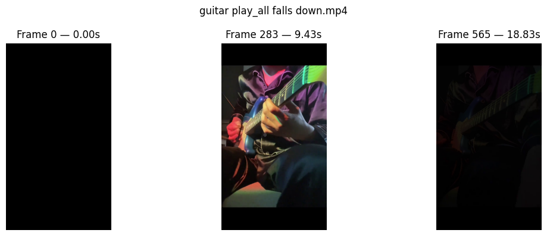

```python
n = frame_count
idxs = [0, n//2 if n > 0 else 0, max(0, n-1)]

def grab_rgb(i):
    cap.set(cv2.CAP_PROP_POS_FRAMES, i)
    ok, bgr = cap.read()
    if not ok or bgr is None:
        return None
    return cv2.cvtColor(bgr, cv2.COLOR_BGR2RGB)

frames = [grab_rgb(i) for i in idxs]

fig, axes = plt.subplots(1, 3, figsize=(12, 4))
for ax, fr, i in zip(axes, frames, idxs):
    ax.axis('off')
    if fr is None:
        ax.set_title(f'Frame {i} — gagal')
    else:
        ax.imshow(fr)
        ts = (i / fps) if ('fps' in globals() and fps and fps > 0) else None
        ax.set_title(f'Frame {i} — {ts:.2f}s' if ts is not None else f'Frame {i}')

title = os.path.basename(video_path) if 'video_path' in globals() else 'Video'
plt.suptitle(title)
plt.tight_layout()
plt.show()
```

### C4. Analisis Ringkas (Wajib)

**Jawab pertanyaan berikut:**

**Kesesuaian parameter:** Apakah fps dan resolusi video ini sesuai untuk use case pilihan Anda (misalnya: media sosial, kuliah daring, presentasi, dll.)? Jelaskan alasan singkat.

*Jawaban Anda:* Sesuai karena video ini berasal dari media sosial dan memang bertujuan utama untuk menunjukan suara , video HD atau 720px sudah cukup

# Perbandingan & Kesimpulan

## Perbandingan Representasi Media

**TODO:** Bandingkan secara ringkas representasi dan visualisasi ketiga media:

### Audio (1D - Temporal)

- Representasi: sampel sinyal 1D dengan sample rate (Hz), bit depth, dan jumlah kanal (mono/stereo).
- Visualisasi utama: waveform , spectrogram log-dB (STFT), MFCC.
- Informasi yang diperoleh: durasi, pola frekuensi/pitch, timbre (MFCC), timing event/tempo.

### Gambar (2D - Spasial)

- Representasi: array H×W×C , bisa juga grayscale atau ruang warna lain.
- Visualisasi utama: tampilan RGB, histogram R/G/B.
- Informasi yang diperoleh: ukuran, warna dominan, kontras dan sebaran intensitas.

### Video (2D + Waktu - Spatio-temporal)

- Representasi: urutan frame (T×H×W×C) beserta metadata (fps, frame count, resolusi, durasi).
- Visualisasi utama: cuplikan frame awal–tengah–akhir, perbandingan antar-frame.
- Informasi yang diperoleh: Resolusi (Width × Height), Frame rate , Jumlah total frame, Durasi , Klasifikasi resolusi.

## Refleksi Pembelajaran

### 3 Poin yang Saya Pelajari:

1. Cara memvisualisasikan file audio, gambar dan video sesuai dengan keperluan.
2. isi-isi dari library yang ada yang bisa membantu dalam pemrosesan data.
3. Cara menganalisa hasil visualisasi data menjadi hal yang berguna.

1. Output yang dihasilkan oleh pemrosesan audio masih membingungkan untuk dibaca

## Sumber Data & Referensi

**TODO:** Cantumkan semua sumber data dan referensi yang digunakan:

- **Audio:** https://youtu.be/FSsh6mY2QYE?si=VxS4qWFW4ISmaVey
- **Gambar:** https://pin.it/1BnGdm6tQ
- **Video:** https://www.tiktok.com/@2_wany/video/7518357553974201601?is_from_webapp=1&sender_device=pc&web_id=7376846571797382672
- **Referensi teknis:** https://jakevdp.github.io/PythonDataScienceHandbook/ , https://docs.opencv.org/4.x/ , https://pillow.readthedocs.io/en/stable

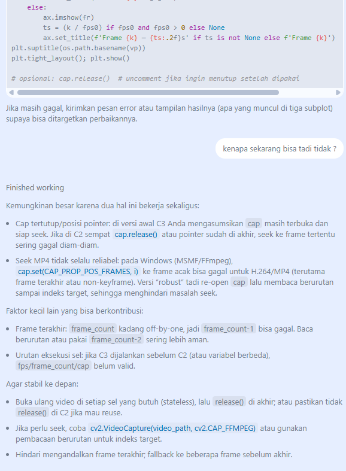

# Rubrik Penilaian

## Distribusi Bobot Penilaian

| **Aspek Penilaian** | **Bobot** | **Deskripsi** |
| --- | --- | --- |
| **Kelengkapan** | **35%** | Semua langkah inti dikerjakan sesuai checklist |
| **Kualitas Visualisasi** | **20%** | Judul, label sumbu, colorbar, legend, keterbacaan plot |
| **Analisis & Interpretasi** | **30%** | Kemampuan interpretasi hasil, bukan sekadar output mentah |
| **Kerapihan & Struktur** | **10%** | Markdown jelas, kode modular, dokumentasi baik |
| **Orisinalitas & Penguasaan** | **5%** | Pemahaman saat presentasi acak |

## Detail Kriteria Penilaian

### 🏆 Kelengkapan (35%)

- ✅ Semua 4 visualisasi audio (metadata, waveform, spectrogram, MFCC)
- ✅ Semua 3 visualisasi gambar (display RGB, metadata, histogram)
- ✅ Semua 2 visualisasi video (metadata, frame extraction)
- ✅ Analisis ringkas untuk setiap bagian

### 📊 Kualitas Visualisasi (20%)

- Plot memiliki judul yang informatif dan deskriptif
- Label sumbu X dan Y jelas dan sesuai
- Colorbar/legend tersedia jika diperlukan
- Ukuran plot proporsional dan mudah dibaca

### 🧠 Analisis & Interpretasi (30%)

- Interpretasi menunjukkan pemahaman konsep
- Analisis kontekstual, bukan sekadar deskripsi output
- Mampu menghubungkan hasil dengan teori
- Refleksi pembelajaran yang thoughtful

### 📝 Kerapihan & Struktur (10%)

- Markdown terstruktur dengan heading yang konsisten
- Kode bersih, terkompartemen, dan mudah dibaca
- Dokumentasi yang memadai
- Flow logical dari satu bagian ke bagian lain

### 🎯 Orisinalitas & Penguasaan (5%)

- **PENTING:** Jika saat presentasi acak Anda tidak mampu menjelaskan kode yang Anda tulis atau menunjukkan ketergantungan buta pada AI/copy-paste, **nilai tugas akan dianggap 0**.
- Kemampuan menjelaskan logika dan alur pemikiran
- Pemahaman konsep di balik implementasi kode

## Proporsi Penilaian Total

- Proporsi penilaian hanya 80%, 20% lagi akan didasarkan pada kecepatan pengumpulan tugas
- Sehingga: 0.8 * penilaian dosen + nilai waktu pengumpulan

# Aturan Kejujuran Akademik

## 📖 Penggunaan Referensi & AI yang Diperbolehkan

Anda **BOLEH** menggunakan:

- ✅ Dokumentasi resmi library (NumPy, Matplotlib, Librosa, OpenCV)
- ✅ Tutorial dan contoh kode dari sumber terpercaya
- ✅ AI tools (ChatGPT, GitHub Copilot, dll.) sebagai **alat bantu pembelajaran**
- ✅ Diskusi dengan teman untuk pemahaman konsep

## ⚠️ Syarat & Batasan WAJIB

Namun Anda **HARUS**:

- 🧠 **Memahami setiap baris kode** yang Anda masukkan ke notebook
- 📝 **Menulis interpretasi dengan kata-kata sendiri**, bukan hasil copy-paste
- 📚 **Mencantumkan sumber data dan referensi** yang digunakan, termasuk transkrip percakapan dengan AI dalam link atau teks
- 🎯 **Mampu menjelaskan logika dan alur pemikiran** saat presentasi acak

## ❌ Pelanggaran yang Berakibat Nilai 0

- **Plagiarisme atau penyalinan buta** dari sumber manapun
- **Copy-paste kode tanpa pemahaman** dan tidak dapat menjelaskan
- **Menggunakan AI untuk mengerjakan seluruh tugas** tanpa pembelajaran personal
- **Tidak dapat menjawab pertanyaan dasar** tentang kode yang dikumpulkan
- **Menyalin pekerjaan teman** atau bekerjasama dalam pengerjaan individual

## 🎯 Persiapan Presentasi Acak

**Kemungkinan pertanyaan yang akan ditanyakan:**

- "Jelaskan mengapa Anda menggunakan parameter ini di STFT?"
- "Apa arti dari pola yang terlihat di MFCC?"
- "Mengapa perlu konversi BGR ke RGB?"
- "Interpretasikan hasil histogram yang Anda buat"
- "Bagaimana cara kerja spectrogram?"

**Tips sukses:**

- Pahami konsep dasar setiap teknik yang digunakan
- Latih menjelaskan dengan bahasa sederhana
- Siapkan justifikasi untuk setiap pilihan parameter
- Kuasai interpretasi setiap visualisasi yang dibuat

# Panduan Pengumpulan

## 📁 Berkas yang Harus Dikumpulkan

### Wajib:

1. **Notebook Jupyter** (.ipynb) dengan nama: `NIM_Nama_TugasMultimedia.ipynb`
   - Contoh: `123456789_JohnDoe_TugasMultimedia.ipynb`
2. **PDF hasil render dari notebook**

## 📅 Informasi Pengumpulan

## ✅ Checklist Sebelum Submit

- [✅] Semua cell sudah dijalankan dan menampilkan output
- [✅] Nama file sesuai format: `NIM_Worksheet2.ipynb` dan `NIM_Worksheet2.pdf`
- [✅] Semua TODO sudah diisi dengan lengkap
- [✅] Analisis dan interpretasi sudah ditulis untuk setiap bagian
- [✅] Sumber data dan referensi sudah dicantumkan

### Export ke PDF:

- File → Save and Export Notebook As → HTML
- Buka HTML di browser -> Save as PDF